# APIs, Twitter, and Text Mining with httr, twitteR, tidytext

David Robinson

April 25, 2016

### Useful Resources

- [httr quickstart guide](https://cran.r-project.org/web/packages/httr/vignettes/quickstart.html)
- [apps.twitter.com](https://apps.twitter.com/): start a Twitter app here before using the twitteR package

### Using an API with httr

Suppose a company has data we’d like to analyze, and they’ve made an API available. How do we use it?

For example, suppose we wanted to do an analysis of Stack Overflow R questions. We would find out that [Stack Exchange has an API](https://api.stackexchange.com/), and choose the search option. This provides us a URL: `https://api.stackexchange.com/docs/search`- and tells us what queries we’d want to fill in.

We can then use httr to make [GET](http://www.w3schools.com/tags/ref_httpmethods.asp) requests.

```r
library(httr)

url <- "https://api.stackexchange.com/2.2/search"

req <- GET(url, query = list(order = "desc",
                             pagesize = 100,
                             sort = "creation",
                             tagged = "r",
                             site = "stackoverflow"))

req
```

```
## Response [https://api.stackexchange.com/2.2/search?order=desc&pagesize=100&sort=creation&tagged=r&site=stackoverflow]
##   Date: 2016-05-08 13:48
##   Status: 200
##   Content-Type: application/json; charset=utf-8
##   Size: 66.1 kB
```

This is a “response” object. You can see it contains a bunch of information, like the date of the request, the size of the response, and the [HTTP status code](https://en.wikipedia.org/wiki/List_of_HTTP_status_codes) (like 200 for a success and 404 for an error). Incidentally, you can check this status code with:

```r
status_code(req)
```

```
## [1] 200
```

This can be useful if you need your program to recognize errors (like `if (status_code(req) != 200)`).

#### Parsing JSON

What we actually care about is the content. You can take a look at it with the `content(req, "text")`.

```r
con <- content(req, "text")
cat(stringr::str_sub(con, 1, 2000))
```

```
## {"items":[{"tags":["r","while-loop"],"owner":{"reputation":53,"user_id":5433002,"user_type":"registered","accept_rate":50,"profile_image":"https://www.gravatar.com/avatar/7d80d19ae1e797efbcf40bc6b4ca46d4?s=128&d=identicon&r=PG&f=1","display_name":"learner ","link":"http://stackoverflow.com/users/…
```

This is called [JSON](http://www.w3schools.com/json/)- it’s one of the most common ways data is returned from the web.

We can use the [jsonlite](https://cran.r-project.org/web/packages/jsonlite/index.html) package to parse this format into a list.

```r
library(jsonlite)

j <- jsonlite::fromJSON(con)
```

Now we figure out how to get the information out of `j`.

```r
summary(j)
```

```
##                 Length Class      Mode
## items           16     data.frame list
## has_more         1     -none-     logical
## quota_max        1     -none-     numeric
## quota_remaining  1     -none-     numeric
```

Clearly it’s `j$items` that we want: the rest is “metadata” about whether the quota has been filled. `j$items` is a data frame:

```r
head(j$items)
```

```
##                               tags owner.reputation owner.user_id
## 1                    r, while-loop               53       5433002
## 2 r, module, shiny, tooltip, ggvis                1       6302564
## 3                                r                1       6304627
## 4                                r               11       1135230
## 5                          r, spss               11       5235404
## 6       r, dataframe, combinations              174       5592518
##   owner.user_type owner.accept_rate
## 1      registered                50
## 2      registered                NA
## 3      registered                NA
## 4      registered                NA
## 5      registered                NA
## 6      registered                83
##                                                                                   owner.profile_image
```

[output cut: 181 more lines]

But several columns within the data frame are themselves data frames. This is actually legal to do- it just leads to some really odd behaviors (in particular, it can’t be combined well with dplyr, even when working with other columns). jsonlite provides a flatten function that fixes this.

```r
library(dplyr)
r_questions <- j$items %>%
    flatten() %>%
    tbl_df()

r_questions
```

```
## Source: local data frame [100 x 43]
##
##        tags is_answered view_count answer_count score last_activity_date
##       (chr)       (lgl)      (int)        (int) (int)              (int)
## 1  <chr[2]>       FALSE         12            0     0         1462714760
## 2  <chr[5]>       FALSE          3            0     0         1462712950
## 3  <chr[1]>       FALSE         22            0     0         1462710471
## 4  <chr[1]>        TRUE         17            1     2         1462710062
## 5  <chr[2]>        TRUE         18            1     0         1462710085
## 6  <chr[3]>       FALSE         30            2     3         1462713085
## 7  <chr[3]>       FALSE          9            0     0         1462706915
## 8  <chr[3]>        TRUE         19            1    -2         1462708791
## 9  <chr[4]>       FALSE         24            0     0         1462705375
## 10 <chr[1]>       FALSE         20            0    -1         1462704172
## ..      ...         ...        ...          ...   ...                ...
## Variables not shown: creation_date (int), last_edit_date (int),
##   question_id (int), link (chr), title (chr), closed_date (int),
##   closed_reason (chr), accepted_answer_id (int), owner.reputation (int),
##   owner.user_id (int), owner.user_type (chr), owner.accept_rate (int),
##   owner.profile_image (chr), owner.display_name (chr), owner.link (chr),
##   migrated_from.on_date (int), migrated_from.question_id (int),
##   migrated_from.other_site.aliases (chr),
##   migrated_from.other_site.related_sites (chr),
##   migrated_from.other_site.markdown_extensions (chr),
##   migrated_from.other_site.launch_date (int),
##   migrated_from.other_site.open_beta_date (int),
##   migrated_from.other_site.closed_beta_date (int),
##   migrated_from.other_site.site_state (chr),
##   migrated_from.other_site.high_resolution_icon_url (chr),
##   migrated_from.other_site.twitter_account (chr),
##   migrated_from.other_site.favicon_url (chr),
##   migrated_from.other_site.icon_url (chr),
##   migrated_from.other_site.audience (chr),
##   migrated_from.other_site.site_url (chr),
##   migrated_from.other_site.api_site_parameter (chr),
##   migrated_from.other_site.logo_url (chr), migrated_from.other_site.name
##   (chr), migrated_from.other_site.site_type (chr),
##   migrated_from.other_site.styling.tag_background_color (chr),
##   migrated_from.other_site.styling.tag_foreground_color (chr),
##   migrated_from.other_site.styling.link_color (chr)
```

We can do cool things with this list of R questions. For example, what are the most common tags on these questions?

```r
library(tidyr)

most_common <- r_questions %>%
    unnest(tag = tags) %>%
    count(tag, sort = TRUE)

most_common
```

```
## Source: local data frame [133 x 2]
##
##               tag     n
##             (chr) (int)
## 1               r   100
## 2           shiny    11
## 3         ggplot2     9
## 4       dataframe     7
## 5  classification     3
## 6      data.table     3
## 7           dplyr     3
## 8      statistics     3
## 9  bioinformatics     2
## 10          graph     2
## ..            ...   ...
```

Of course the `r` tag is used on all of them, and it looks like other common tags include ggplot2 and dataframe.

You may want to put all the querying and processing steps into one function:

```r
search_stack_overflow <- function(...) {
    url <- "https://api.stackexchange.com/2.2/search"
    req <- GET(url, query = list(...))

    con <- content(req, "text")
    ret <- flatten(fromJSON(con)$items)
    tbl_df(ret)
}

search_stack_overflow(order = "desc",
                      pagesize = 100,
                      sort = "creation",
                      tagged = "r",
                      site = "stackoverflow")
```

```
## Source: local data frame [100 x 43]
##
##        tags is_answered view_count answer_count score last_activity_date
##       (chr)       (lgl)      (int)        (int) (int)              (int)
## 1  <chr[2]>       FALSE         12            0     0         1462714760
## 2  <chr[5]>       FALSE          3            0     0         1462712950
## 3  <chr[1]>       FALSE         22            0     0         1462710471
## 4  <chr[1]>        TRUE         17            1     2         1462710062
## 5  <chr[2]>        TRUE         18            1     0         1462710085
## 6  <chr[3]>       FALSE         30            2     3         1462713085
## 7  <chr[3]>       FALSE          9            0     0         1462706915
## 8  <chr[3]>        TRUE         19            1    -2         1462708791
## 9  <chr[4]>       FALSE         24            0     0         1462705375
## 10 <chr[1]>       FALSE         20            0    -1         1462704172
## ..      ...         ...        ...          ...   ...                ...
## Variables not shown: creation_date (int), last_edit_date (int),
##   question_id (int), link (chr), title (chr), closed_date (int),
##   closed_reason (chr), accepted_answer_id (int), owner.reputation (int),
##   owner.user_id (int), owner.user_type (chr), owner.accept_rate (int),
##   owner.profile_image (chr), owner.display_name (chr), owner.link (chr),
##   migrated_from.on_date (int), migrated_from.question_id (int),
##   migrated_from.other_site.aliases (chr),
##   migrated_from.other_site.related_sites (chr),
##   migrated_from.other_site.markdown_extensions (chr),
##   migrated_from.other_site.launch_date (int),
##   migrated_from.other_site.open_beta_date (int),
##   migrated_from.other_site.closed_beta_date (int),
##   migrated_from.other_site.site_state (chr),
##   migrated_from.other_site.high_resolution_icon_url (chr),
##   migrated_from.other_site.twitter_account (chr),
##   migrated_from.other_site.favicon_url (chr),
##   migrated_from.other_site.icon_url (chr),
##   migrated_from.other_site.audience (chr),
##   migrated_from.other_site.site_url (chr),
##   migrated_from.other_site.api_site_parameter (chr),
##   migrated_from.other_site.logo_url (chr), migrated_from.other_site.name
##   (chr), migrated_from.other_site.site_type (chr),
##   migrated_from.other_site.styling.tag_background_color (chr),
##   migrated_from.other_site.styling.tag_foreground_color (chr),
##   migrated_from.other_site.styling.link_color (chr)
```

There’s a lot more complexity here. For example, this returns only 100 items. You can use the `page` argument, [as described here](https://api.stackexchange.com/docs/paging) to get additional pages of output.

In fact, this complexity, and lots more, is handled by my R client to Stack Overflow, stackr:

```r
library(stackr)

r_questions_500 <- stack_search(tagged = "r", pagesize = 100, num_pages = 5)

tbl_df(r_questions_500)
```

```
## Source: local data frame [500 x 46]
##
##                            tags is_answered view_count answer_count score
##                           (chr)       (lgl)      (int)        (int) (int)
## 1                  r,while-loop       FALSE         13            0     0
## 2                         r,nan        TRUE         39            1     1
## 3      r,dataframe,combinations       FALSE         31            2     3
## 4  r,module,shiny,tooltip,ggvis       FALSE          4            0     0
## 5           r,data-manipulation        TRUE         64            2    -1
## 6  r,neural-network,time-series        TRUE       9711            2     7
## 7            r,data.table,dplyr       FALSE         37            0    -1
## 8                             r       FALSE         23            0     0
## 9                        r,spss        TRUE         18            1     0
## 10                            r        TRUE         17            1     2
## ..                          ...         ...        ...          ...   ...
## Variables not shown: last_activity_date (time), creation_date (time),
##   last_edit_date (time), question_id (int), link (chr), title (chr),
##   closed_date (time), closed_reason (chr), accepted_answer_id (int),
##   bounty_amount (int), bounty_closes_date (time), owner_reputation (int),
##   owner_user_id (int), owner_user_type (chr), owner_accept_rate (int),
##   owner_profile_image (chr), owner_display_name (chr), owner_link (chr),
##   migrated_from_on_date (time), migrated_from_question_id (int),
##   migrated_from_other_site_aliases (chr),
##   migrated_from_other_site_related_sites (chr),
##   migrated_from_other_site_markdown_extensions (chr),
##   migrated_from_other_site_launch_date (time),
##   migrated_from_other_site_open_beta_date (time),
##   migrated_from_other_site_closed_beta_date (time),
##   migrated_from_other_site_site_state (chr),
##   migrated_from_other_site_high_resolution_icon_url (chr),
##   migrated_from_other_site_twitter_account (chr),
##   migrated_from_other_site_favicon_url (chr),
##   migrated_from_other_site_icon_url (chr),
##   migrated_from_other_site_audience (chr),
##   migrated_from_other_site_site_url (chr),
##   migrated_from_other_site_api_site_parameter (chr),
##   migrated_from_other_site_logo_url (chr), migrated_from_other_site_name
##   (chr), migrated_from_other_site_site_type (chr),
##   migrated_from_other_site_styling_tag_background_color (chr),
##   migrated_from_other_site_styling_tag_foreground_color (chr),
##   migrated_from_other_site_styling_link_color (chr), protected_date (time)
```

Generally it’s easier to work with a package like this. But what’s important to understand is that API packages like this use the exact same functionality, or very similar, of working with GET queries as above.

Thus, when you want to query a site, it’s often a good idea to look for an R package to do it first (try googling “r package [site] api”). These handle a lot of complexitly. But if none is available, or if it doesn’t have the functionality you want, it’s important to know how to use the httr package and understand the fundamentals of API interfaces.

### Working with Twitter client

[twitteR](https://cran.r-project.org/web/packages/twitteR/README.html) is a good example of an R package that handles an online client API.

#### Twitter Setup

```r
library(twitteR)
```

To get this to work, you’ll need some setup. Follow the steps [here](https://cran.r-project.org/web/packages/twitteR/README.html) to get your own Twitter application- in the process it will give you four values. Put those values into global options using this code:

```r
options(twitter_consumer_key = "YOUR_KEY_HERE")
options(twitter_consumer_secret = "YOUR_SECRET_HERE")
options(twitter_access_token = 'YOUR_ACCESS_TOKEN_HERE')
options(twitter_access_token_secret = "YOUR_ACCESS_TOKEN_SECRET_HERE")
```

(Fill in those values with the ones from your Twitter app first). I generally put this in my .Rprofile file in my home directory (see [here](http://www.statmethods.net/interface/customizing.html)). This a) makes sure they are always available, and b) keeps them secret, so they’re not in any of my scripts.

Then you can run this code to set up your authentication:

```r
setup_twitter_oauth(getOption("twitter_consumer_key"),
                     getOption("twitter_consumer_secret"),
                     getOption("twitter_access_token"),
                     getOption("twitter_access_token_secret"))
```

#### Search Twitter

Suppose we want to do an analysis of the #rstats hashtag, for example. The `searchTwitter` function lets you do this.

```r
setup_twitter_oauth("cDJ9eqhEXlUPWeY7bV2TbmRNF","FYKaGkwJJx41AM6I4QFn8jBceSzSuQtNaqdMuRAYOB5XluefUY","3607051577-ndbDsuzThV5SYzFUrGQeGcttIDxKXd8RmWOxYY3","UotKyPNTDAcL4etQ9gBs5SK31CDoiFKufxMwY2GXUMagR")
```

```
## [1] "Using direct authentication"
```

```r
rstats <- searchTwitter("#rstats", n = 500)
```

```r
# I've found this is slow and unreliable in knitr, so I'm leaving
# this run separately
#load("~/Dropbox/rstats.rda")
```

This looks like it’s a list of character vectors containing tweets. Each of these is actually a “status” object, including additional information like who tweeted it and when it was posted. Generally, it is a good idea to turn this into a tbl_df, and there’s a handy trick for this::

```r
rstats_tweets <- bind_rows(lapply(rstats, as.data.frame))

rstats_tweets
```

```
## Source: local data frame [500 x 16]
##
##                                                                            text
##                                                                           (chr)
## 1   Top story: #rstats Shiny Apps Gallery using Plotly in R | R-bloggers https:
## 2   RT @seandavis12: Anyone working on #docker #rstats packages similar to dock
## 3   RT @seandavis12: New #shiny #rstats videos https://t.co/dnIbZhWe84 from @rs
## 4  RT @sthda_en: ggplot2 Essentials - Elegant Data visualization in #rstats\nQu
## 5   RT @hadleywickham: ICYMI: all the videos from shinyconf are now available:
## 6   RT @hadleywickham: ICYMI: all the videos from shinyconf are now available:
## 7   RT @revodavid: R Tools for Visual Studio @RT4VS adds Excel data views, in-s
## 8   Amazing talk on shiny by @rstudio's @jcheng  @earlconf London 2015 https://
## 9   RT @josephsirosh: R+ SQL Server 2016 makes for a powerful extensible data s
## 10  RT @Rbloggers: Too Much Parallelism is as Bad https://t.co/t0RffUvLYs #rsta
## ..                                                                          ...
## Variables not shown: favorited (lgl), favoriteCount (dbl), replyToSN
##   (chr), created (time), truncated (lgl), replyToSID (chr), id (chr),
##   replyToUID (chr), statusSource (chr), screenName (chr), retweetCount
##   (dbl), isRetweet (lgl), retweeted (lgl), longitude (lgl), latitude (lgl)
```

#### Analyzing Tweets

Note that this includes retweets alongside originals. If we want to do an analysis of individual tweets, we’d probably want to filter those out:

```r
rstats_non_retweets <- rstats_tweets %>%
    filter(!isRetweet)
```

```r
rstats_non_retweets %>%
    count(screenName, sort = TRUE)
```

```
## Source: local data frame [94 x 2]
##
##         screenName     n
##              (chr) (int)
## 1  CRANberriesFeed     8
## 2        Rbloggers     6
## 3        dataandme     5
## 4        lenkiefer     5
## 5  michaeljwgrogan     5
## 6       sfrechette     5
## 7  ImDataScientist     3
## 8  AnalyticsFrance     2
## 9         benakiva     2
## 10    BestCourses_     2
## ..             ...   ...
```

You could make a histogram about how often each was retweeted:

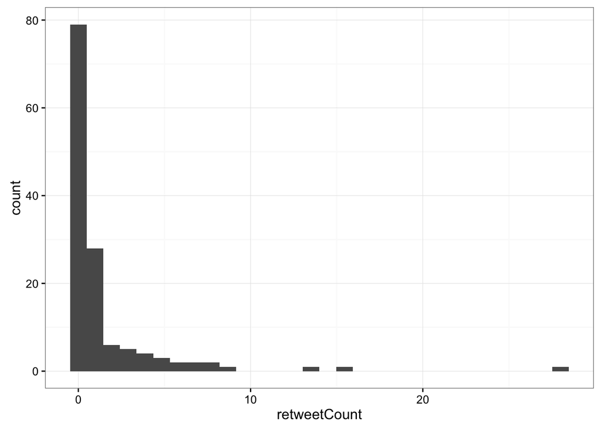

```r
library(ggplot2)
ggplot(rstats_non_retweets, aes(retweetCount)) +
    geom_histogram()
```

### Text Mining and Tokens

There are many approaches to text mining in R, and I will link to some. The one I’m discussing is very new- I developed it with Julia Silge just a month ago- but I like the way it allows engagement with text with dplyr and ggplot2.

One example we use to demonstrate is the book Pride and Prejudice. You can use the `janeaustenr` package on CRAN for this.

```r
library(janeaustenr)

head(prideprejudice, 20)
```

```
##  [1] "PRIDE AND PREJUDICE"
##  [2] ""
##  [3] "By Jane Austen"
##  [4] ""
##  [5] ""
##  [6] ""
##  [7] "Chapter 1"
##  [8] ""
##  [9] ""
## [10] "It is a truth universally acknowledged, that a single man in possession"
## [11] "of a good fortune, must be in want of a wife."
## [12] ""
## [13] "However little known the feelings or views of such a man may be on his"
## [14] "first entering a neighbourhood, this truth is so well fixed in the minds"
## [15] "of the surrounding families, that he is considered the rightful property"
## [16] "of some one or other of their daughters."
## [17] ""
## [18] "\"My dear Mr. Bennet,\" said his lady to him one day, \"have you heard that"
## [19] "Netherfield Park is let at last?\""
## [20] ""
```

The tidy approach to text mining keeps everything in data frames. Start with a one-row-per-line data frame.

```r
book <- data_frame(text = prideprejudice)
book
```

```
## Source: local data frame [12,447 x 1]
##
##                                                                       text
##                                                                      (chr)
## 1                                                      PRIDE AND PREJUDICE
## 2
## 3                                                           By Jane Austen
## 4
## 5
## 6
## 7                                                                Chapter 1
## 8
## 9
## 10 It is a truth universally acknowledged, that a single man in possession
## ..                                                                     ...
```

Now, the tidytext package offers the `unnest_tokens` function. This does tokenization- which divides text into a sequence of meaningful units, like words or sentences- on a data frame with a text column.

```r
library(tidytext)

book %>%
    unnest_tokens(word, text)
```

```
## Source: local data frame [122,204 x 1]
##
##         word
##        (chr)
## 1      pride
## 2        and
## 3  prejudice
## 4         by
## 5       jane
## 6     austen
## 7    chapter
## 8          1
## 9         it
## 10        is
## ..       ...
```

```r
stop_words
```

```
## Source: local data frame [1,149 x 2]
##
##           word lexicon
##          (chr)   (chr)
## 1            a   SMART
## 2          a's   SMART
## 3         able   SMART
## 4        about   SMART
## 5        above   SMART
## 6    according   SMART
## 7  accordingly   SMART
## 8       across   SMART
## 9     actually   SMART
## 10       after   SMART
## ..         ...     ...
```

```r
book %>%
    unnest_tokens(word, text) %>%
    filter(!word %in% stop_words$word)
```

```
## Source: local data frame [37,246 x 1]
##
##            word
##           (chr)
## 1         pride
## 2     prejudice
## 3          jane
## 4        austen
## 5       chapter
## 6             1
## 7         truth
## 8   universally
## 9  acknowledged
## 10       single
## ..          ...
```

### Tokenizing sentences, paragraphs, or characters

Tokenizing doesn’t have to be by word. We can divide it by paragraph:

```r
book %>%
    unnest_tokens(paragraph, text, token = "paragraphs")
```

```
## Source: local data frame [1,579 x 1]
##
##                                                                      paragraph
##                                                                          (chr)
## 1                                                          pride and prejudice
## 2                                                               by jane austen
## 3                                                                    chapter 1
## 4   it is a truth universally acknowledged, that a single man in possession of
## 5  however little known the feelings or views of such a man may be on his firs
## 6  "my dear mr. bennet," said his lady to him one day, "have you heard that ne
## 7                                          mr. bennet replied that he had not.
## 8  "but it is," returned she; "for mrs. long has just been here, and she told
## 9                                                   mr. bennet made no answer.
## 10     "do you not want to know who has taken it?" cried his wife impatiently.
## ..                                                                         ...
```

(Note that what we name the output column, `paragraph` in this case, doesn’t affect it, it’s just good to give it a consistent name). We could also divide it by sentence:

```r
book %>%
    unnest_tokens(sentence, text, token = "sentences")
```

```
## Source: local data frame [7,066 x 1]
##
##                                                                       sentence
##                                                                          (chr)
## 1  pride and prejudice  by jane austen    chapter 1   it is a truth universall
## 2  however little known the feelings or views of such a man may be on his firs
## 3                                                                 "my dear mr.
## 4  bennet," said his lady to him one day, "have you heard that netherfield par
## 5                                                                          mr.
## 6                                              bennet replied that he had not.
## 7                                         "but it is," returned she; "for mrs.
## 8                      long has just been here, and she told me all about it."
## 9                                                                          mr.
## 10                                                      bennet made no answer.
## ..                                                                         ...
```

(Note that this is tricked by terms like “Mr.” and “Mrs.”).

One neat trick is that we can unnest by two layers- paragraph and then word. This lets us keep track of which paragraph is which.

```r
paragraphs <- book %>%
    unnest_tokens(paragraph, text, token = "paragraphs") %>%
    mutate(paragraph_number = row_number()) %>%
    slice(-n())

# (Quick note: the `slice` is because the last paragraph has some
# formatting issues in this version of janeaustenr, so we're dropping it).

words_by_paragraph <- paragraphs %>%
    unnest_tokens(word, paragraph) %>%
    filter(!word %in% stop_words$word)

words_by_paragraph
```

```
## Source: local data frame [29,179 x 2]
##
##    paragraph_number         word
##               (int)        (chr)
## 1                 1        pride
## 2                 1    prejudice
## 3                 2         jane
## 4                 2       austen
## 5                 3      chapter
## 6                 3            1
## 7                 4        truth
## 8                 4  universally
## 9                 4 acknowledged
## 10                4       single
## ..              ...          ...
```

Similarly, we could use this tokenization approach on Twitter data:

```r
tweet_words <- rstats_non_retweets %>%
    select(screenName, id, created, text) %>%
    unnest_tokens(word, text) %>%
    filter(!word %in% stop_words$word)

tweet_words
```

```
## Source: local data frame [1,437 x 4]
##
##    screenName                 id             created     word
##         (chr)              (chr)              (time)    (chr)
## 1  sfrechette 729369060765511680 2016-05-08 17:55:09      top
## 2  sfrechette 729369060765511680 2016-05-08 17:55:09    story
## 3  sfrechette 729369060765511680 2016-05-08 17:55:09   rstats
## 4  sfrechette 729369060765511680 2016-05-08 17:55:09    shiny
## 5  sfrechette 729369060765511680 2016-05-08 17:55:09     apps
## 6  sfrechette 729369060765511680 2016-05-08 17:55:09  gallery
## 7  sfrechette 729369060765511680 2016-05-08 17:55:09   plotly
## 8  sfrechette 729369060765511680 2016-05-08 17:55:09 bloggers
## 9  sfrechette 729369060765511680 2016-05-08 17:55:09    https
## 10 sfrechette 729369060765511680 2016-05-08 17:55:09     t.co
## ..        ...                ...                 ...      ...
```

```r
tweet_words %>%
    count(word, sort = TRUE)
```

```
## Source: local data frame [709 x 2]
##
##           word     n
##          (chr) (int)
## 1       rstats   137
## 2        https   129
## 3         t.co   129
## 4  datascience    25
## 5        shiny    19
## 6         data    13
## 7      dataviz    11
## 8        house    10
## 9        runif    10
## 10        cran     9
## ..         ...   ...
```

#### Sentiment Analysis

One of the simpler things to do with text is to treat each text as a “bag of words.”

Meet the sentiments dictionary, also from the tidytext package.

```r
sentiments
```

```
## Source: local data frame [23,165 x 4]
##
##           word sentiment lexicon score
##          (chr)     (chr)   (chr) (int)
## 1       abacus     trust     nrc    NA
## 2      abandon      fear     nrc    NA
## 3      abandon  negative     nrc    NA
## 4      abandon   sadness     nrc    NA
## 5    abandoned     anger     nrc    NA
## 6    abandoned      fear     nrc    NA
## 7    abandoned  negative     nrc    NA
## 8    abandoned   sadness     nrc    NA
## 9  abandonment     anger     nrc    NA
## 10 abandonment      fear     nrc    NA
## ..         ...       ...     ...   ...
```

There are other lexicons in this dataset (see `?sentiments` for more) but we’ll use the NRC dataset first. This dataset associates each word with one or more moods, such as “anger”, “joy”, or “sadness”.

```r
nrc <- sentiments %>%
    filter(lexicon == "nrc") %>%
    select(word, sentiment)

nrc
```

```
## Source: local data frame [13,901 x 2]
##
##           word sentiment
##          (chr)     (chr)
## 1       abacus     trust
## 2      abandon      fear
## 3      abandon  negative
## 4      abandon   sadness
## 5    abandoned     anger
## 6    abandoned      fear
## 7    abandoned  negative
## 8    abandoned   sadness
## 9  abandonment     anger
## 10 abandonment      fear
## ..         ...       ...
```

We want to match these word-sentiment pairs to our book. The `inner_join` function from dplyr is perfect for this.

```r
words_by_paragraph %>%
    inner_join(nrc)
```

```
## Source: local data frame [20,787 x 3]
##
##    paragraph_number       word sentiment
##               (int)      (chr)     (chr)
## 1                 1      pride       joy
## 2                 1      pride  positive
## 3                 1  prejudice     anger
## 4                 1  prejudice  negative
## 5                 4      truth  positive
## 6                 4      truth     trust
## 7                 4 possession     anger
## 8                 4 possession   disgust
## 9                 4 possession      fear
## 10                4 possession  negative
## ..              ...        ...       ...
```

```r
words_paragraph_sentiment <- words_by_paragraph %>%
    inner_join(nrc) %>%
    count(sentiment, paragraph_number) %>%
    spread(sentiment, n, fill = 0) %>%
    mutate(positivity = (positive - negative) / (positive + negative + 1))

words_paragraph_sentiment
```

```
## Source: local data frame [1,353 x 12]
##
##    paragraph_number anger anticipation disgust  fear   joy negative
##               (int) (dbl)        (dbl)   (dbl) (dbl) (dbl)    (dbl)
## 1                 1     1            0       0     0     1        1
## 2                 4     1            1       1     1     1        1
## 3                 5     0            0       0     0     0        0
## 4                 6     0            0       0     0     0        0
## 5                11     1            0       0     1     0        2
## 6                12     0            1       0     0     0        0
## 7                13     1            3       1     1     2        2
## 8                17     0            1       0     0     1        0
## 9                19     0            0       0     0     0        1
## 10               21     0            0       0     0     1        2
## ..              ...   ...          ...     ...   ...   ...      ...
## Variables not shown: positive (dbl), sadness (dbl), surprise (dbl), trust
##   (dbl), positivity (dbl)
```

What is the most positive sentence?

```r
words_paragraph_sentiment %>%
    arrange(desc(positivity))
```

```
## Source: local data frame [1,353 x 12]
##
##    paragraph_number anger anticipation disgust  fear   joy negative
##               (int) (dbl)        (dbl)   (dbl) (dbl) (dbl)    (dbl)
## 1               575     0            6       0     0     7        0
## 2               649     0            2       0     0     6        0
## 3               750     0            3       0     0     3        0
## 4               138     0            9       0     1     8        0
## 5               282     1            2       0     0     3        0
## 6               969     0            5       0     0     3        0
## 7               974     0            3       0     1     8        0
## 8               580     0            4       0     0     3        0
## 9               653     0            1       0     0     4        0
## 10              441     0            0       0     1     1        0
## ..              ...   ...          ...     ...   ...   ...      ...
## Variables not shown: positive (dbl), sadness (dbl), surprise (dbl), trust
##   (dbl), positivity (dbl)
```

```r
paragraphs %>%
    filter(paragraph_number == 575) %>%
    .$paragraph
```

```
## [1] "the prospect of the netherfield ball was extremely agreeable to every female of the family. mrs. bennet chose to consider it as given in compliment to her eldest daughter, and was particularly flattered by receiving the invitation from mr. bingley himself, instead of a ceremonious card. jane…
```

That looks about right! What is the most negative paragraph?

```r
words_paragraph_sentiment %>%
    arrange(positivity)
```

```
## Source: local data frame [1,353 x 12]
##
##    paragraph_number anger anticipation disgust  fear   joy negative
##               (int) (dbl)        (dbl)   (dbl) (dbl) (dbl)    (dbl)
## 1               774     6            0       5     5     0        8
## 2              1029     1            1       2     2     0        5
## 3               770     3            2       0     0     0        4
## 4               902     3            2       1     2     0        4
## 5              1274     1            0       0     3     0        4
## 6                52     1            0       0     1     0        3
## 7                62     0            0       1     0     0        3
## 8               114     1            0       1     2     0        3
## 9               216     1            0       0     0     0        3
## 10              218     1            0       1     3     0        3
## ..              ...   ...          ...     ...   ...   ...      ...
## Variables not shown: positive (dbl), sadness (dbl), surprise (dbl), trust
##   (dbl), positivity (dbl)
```

```r
paragraphs %>%
    filter(paragraph_number == 774) %>%
    .$paragraph
```

```
## [1] "mrs. bennet was really in a most pitiable state. the very mention of anything concerning the match threw her into an agony of ill-humour, and wherever she went she was sure of hearing it talked of. the sight of miss lucas was odious to her. as her successor in that house, she regarded her wi…
```

Plausible again!